# 09.Example 1

Modified

We 2026-09-16 13:21

## Given:

A system for heating water from an inlet temperature of $T_{m,i} = 20\ \mathrm{°C}$ to an outlet temperature of $T_{m,o} = 60\ \mathrm{°C}$ involves passing the water through a thick walled tube having inner and outer diameters of $20\ \mathrm{mm}$ and $40\ \mathrm{mm}$. The outer surface of the tube is well insulated, and electrical heating within the wall provides for a uniform generation rate of $\dot{q} = 1.0\ \frac{\mathrm{MW}}{\mathrm{m}^{3}}$.

## Required:

1. For a water mass flow rate of $\dot{m} = 0.1\ \frac{\mathrm{kg}}{\mathrm{s}}$, how long must the tube be to achieve the desired outlet temperature?
2. If the inner surface temperature of the tube is $T_{s,o} = 70\ \mathrm{°C}$ at the outlet, what is the local convection heat transfer coefficient at the outlet?

## Solution:

Start first by defining all of the given values.

$$T_{m,i} = 20\ \mathrm{°C} = 293.15\ \mathrm{K}$$
$$T_{m,o} = 60\ \mathrm{°C} = 333.15\ \mathrm{K}$$
$$D_i = 20\ \mathrm{mm}$$
$$D_o = 40\ \mathrm{mm}$$
$$\dot{q} = 1.0\ \frac{\mathrm{MW}}{\mathrm{m}^{3}}$$
$$\dot{m} = 0.1\ \frac{\mathrm{kg}}{\mathrm{s}}$$
$$T_{s,o} = 70\ \mathrm{°C} = 343.15\ \mathrm{K}$$

A diagram of the system is shown below.

Figure 1: System Diagram

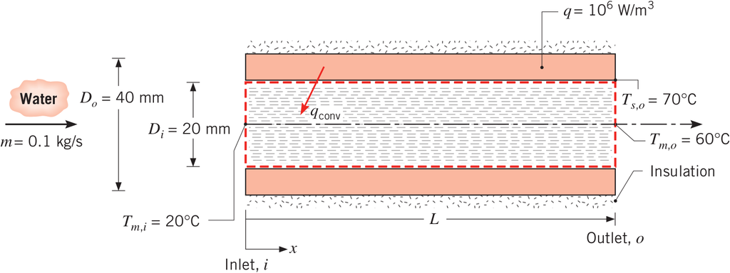

The fluid properties will be evaluated at the average mean temperature. This is given by

$$\bar{T}_m = \frac{T_{mo} + T_{mi}}{2} = 313.1\ \mathrm{K} = 40.0\ \mathrm{°C}$$

Going to Table A.6 at $\bar{T}_m$ shows that interpolation is needed. This is shown below.

$$T_A = 310\ \mathrm{K} = 36.9\ \mathrm{°C}$$
$$T_B = 315\ \mathrm{K} = 41.9\ \mathrm{°C}$$
$$c_{p,A} = 4.178\ \frac{\mathrm{kJ}}{\left(\mathrm{K} \cdot \mathrm{kg}\right)}$$
$$c_{p,B} = 4.179\ \frac{\mathrm{kJ}}{\left(\mathrm{K} \cdot \mathrm{kg}\right)}$$
$$c_p = \frac{\bar{T_m} - T_A}{T_B - T_A}(c_{pB} - c_{pA}) + c_{pA} = 4.179\ \frac{\mathrm{kJ}}{\left(\mathrm{K} \cdot \mathrm{kg}\right)}$$

Starting with an energy balance around the volume of the pipe shows

$$\frac{dE_{sys}}{dt}=\Sigma \dot{E}_{in} - \Sigma \dot{E}_{out}$$

Assuming steady state conditions shows

$$0=\Sigma \dot{E}_{in} - \Sigma \dot{E}_{out}$$

The energy entering the pipe is through the heat generation term and is given by

$$\Sigma \dot{E}_{in} = \dot{q} V = q \frac{\pi}{4}\left( D_o^2 - D_i^2 \right)L$$

The energy leaving the pipe is due to the convection heat rate to the fluid and as previous shown in the lecture notes is given by

$$\Sigma \dot{E}_{out} = q_{conv} = \dot{m} c_p \left( T_{m,o} - T_{m,i} \right)$$

The energy balance then becomes

$$0=\dot{q} \frac{\pi}{4}\left( D_o^2 - D_i^2 \right)L - \dot{m} c_p \left( T_{m,o} - T_{m,i} \right)$$

Solving for the length $L$ of the pipe shows

Answer, part (a): $L = \frac{4 \dot{m} c_p (T_{mo} - T_{mi})}{\pi \dot{q} (D_o^2 - D_i^2)} = 17.73\ \mathrm{m}$

Assuming that the heat generation term produces a constant surface heat flux condition on the pipe, the surface heat flux may be found

$$q^{\prime \prime} = \frac{\dot{q} V}{A_s} = \frac{q\frac{\pi}{4}( D_o^2 - D_i^2 )L}{\pi D_i L} = \frac{\dot{q} ( D_o^2 - D_i^2 )}{4 D_i} = 15.0\ \frac{\mathrm{kW}}{\mathrm{m}^{2}}$$

Using Newton’s law of cooling the convective coefficient at the outlet may be found. This is shown below.

$$q^{''}_s=h_o \left( T_{s,o} - T_{m,o} \right)$$

Solving for the convective coefficient shows

Answer, part (b): $h_o = \frac{q^{\prime \prime}_s}{T_{so}-T_{mo}} = 1.5\ \frac{\mathrm{kW}}{\left(\mathrm{K} \cdot \mathrm{m}^{2}\right)}$